# Methods of Empirical Finance

## Seminar (UE)

### Christoph Huber

### University of Innsbruck

#### Master in Banking and Finance

### Winter term 2019/20 (this version: 2019-12-03)

# Regression Analysis

### Methods of Empirical Finance

<footer></footer>

# Regression Analysis

### A simple (univariate) linear regression model

`\(y_i = \alpha + \beta\;x_i + \varepsilon_i\)`

with `\(i \in \left[ 1, 2, . . . , n \right]\)` referring to the `\(i\)`th observation

`\(\alpha ...\)` intercept (often denoted `\(\beta_0\)`)

`\(\beta ...\)` slope coefficient

`\(\varepsilon ...\)` a random disturbance term

<footer></footer>

# Regression Analysis

### Example: Download stock price data

```r
library(tidyverse)
library(tidyquant)

sp500 <- tq_get("^GSPC")  # download S&P500 prices
nflx <- tq_get("NFLX")	  # download Netflix (NFLX) prices
msft <- tq_get("MSFT")    # download Microsoft (MSFT) prices
```

Stata:

`getsymbols` command (install using `ssc install getsymbols`)

<footer></footer>

# Regression Analysis

### Example: MSFT prices

|  | date | open | high | low | close | volume | adjusted |
| --- | --- | --- | --- | --- | --- | --- | --- |
| 1 | 2009-01-02 | 19.530001 | 20.4 | 19.370001 | 20.33 | 50084000 | 15.635055 |
| 2 | 2009-01-05 | 20.200001 | 20.67 | 20.059999 | 20.52 | 61475200 | 15.781175 |
| 3 | 2009-01-06 | 20.75 | 21 | 20.610001 | 20.76 | 58083400 | 15.96575 |
| 4 | 2009-01-07 | 20.190001 | 20.290001 | 19.48 | 19.51 | 72709900 | 15.004425 |
| 5 | 2009-01-08 | 19.629999 | 20.190001 | 19.549999 | 20.120001 | 70255400 | 15.473547 |
| 6 | 2009-01-09 | 20.17 | 20.299999 | 19.41 | 19.52 | 49815300 | 15.012109 |
| 7 | 2009-01-12 | 19.709999 | 19.790001 | 19.299999 | 19.469999 | 52163500 | 14.97366 |
| 8 | 2009-01-13 | 19.52 | 19.99 | 19.52 | 19.82 | 65843500 | 15.242832 |
| 9 | 2009-01-14 | 19.530001 | 19.68 | 19.01 | 19.09 | 80257500 | 14.681418 |
| 10 | 2009-01-15 | 19.07 | 19.299999 | 18.52 | 19.24 | 96169800 | 14.796769 |

[output cut: 10 more lines]

<footer></footer>

# Regression Analysis

### Example: Plot price development

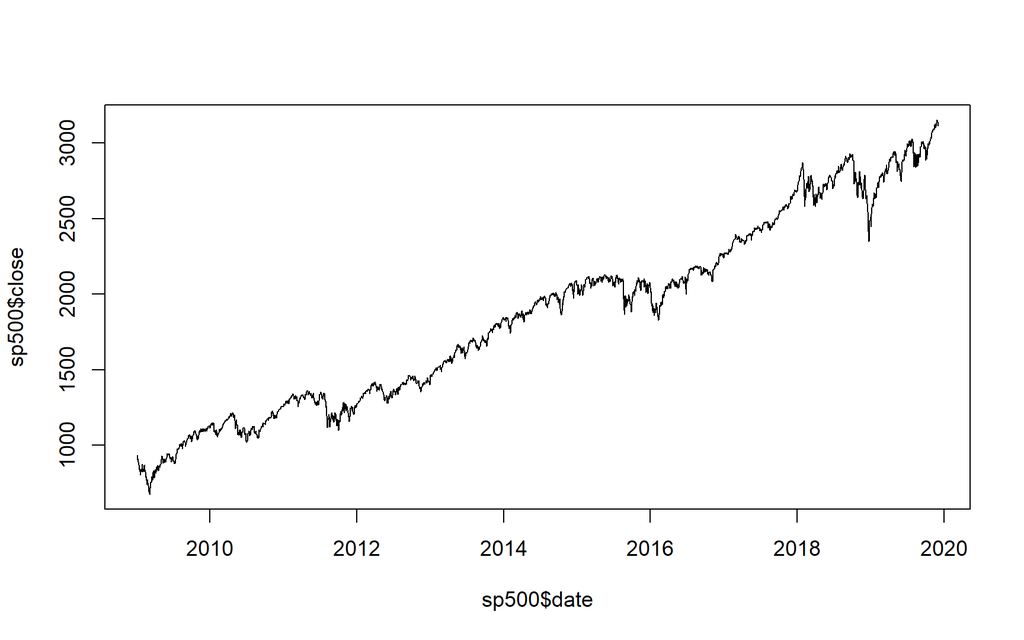

```r
plot(sp500$date, sp500$close, type = "l")
```

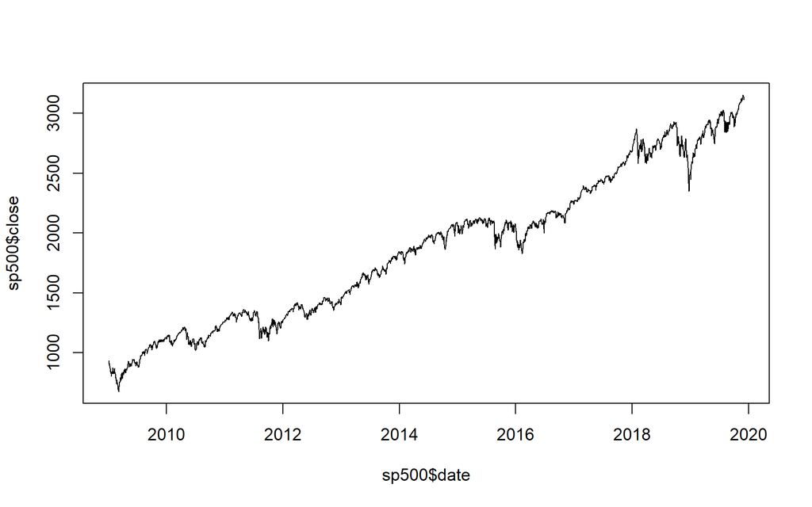

```r
plot(sp500$date, sp500$close, type = "l")
```

<footer></footer>

# Regression Analysis

### Example: Plot price development (`ggplot2`)

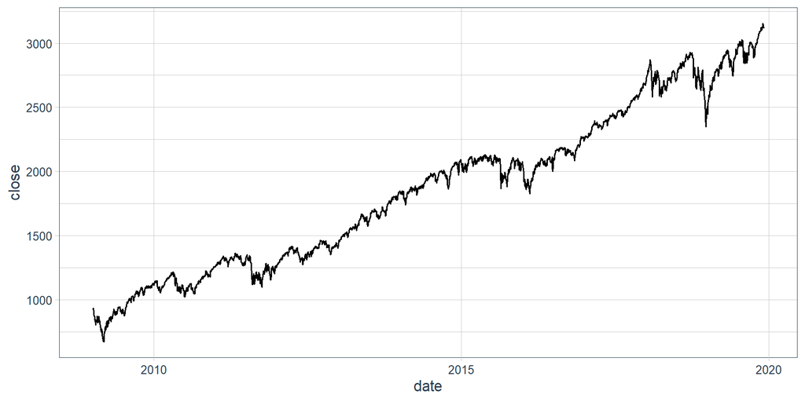

```r
sp500 %>%
  ggplot(aes(x = date, y = close)) +
  geom_line() +
  theme_tq()
```

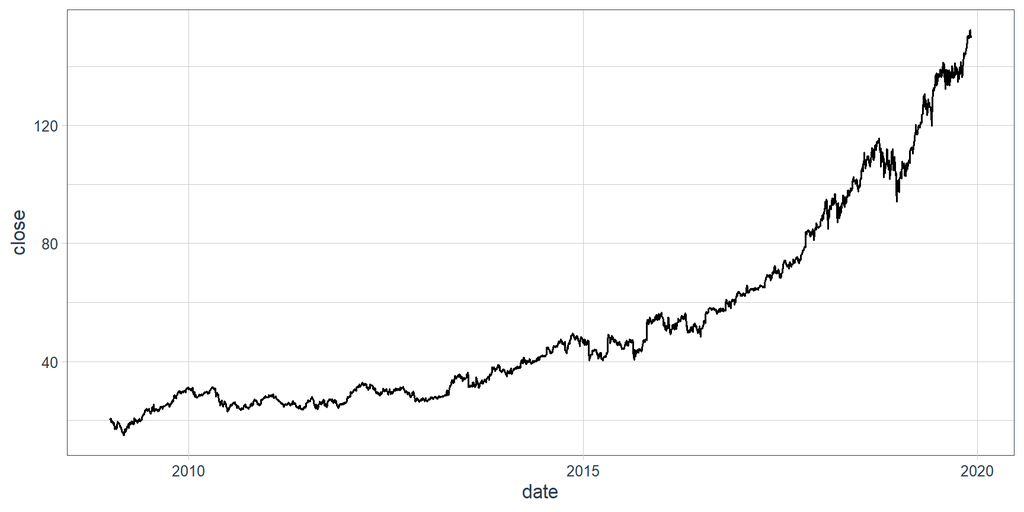

```r
msft %>%
  ggplot(aes(x = date, y = close)) +
  geom_line() +
  theme_tq()
```

<footer></footer>

# Regression Analysis

### Example: Correlation of Returns

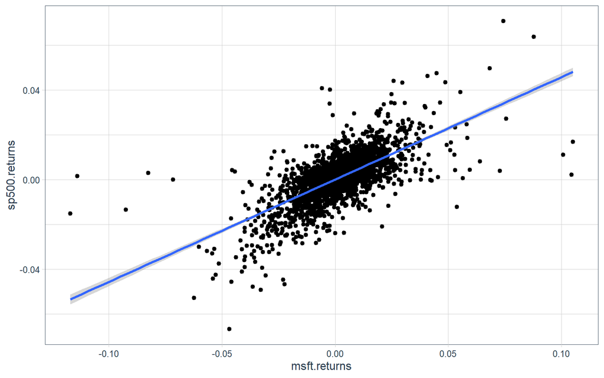

<footer></footer>

# Regression Analysis

### Example: Estimating portfolio characteristics using OLS

CAPM:

`\(E(R_i) - R_f = \beta_i(E(R_M) - R_f)\)`

This implies the following linear model:

`\(E(R_i) = \alpha_i  + \beta_i E(R_M),\)`

where `\(\alpha_i \neq 0\)` unless `\(\beta_i = 1\)`.

We can then express the single index model in the form

`\(R_{it} = \alpha_i + \beta_i X_t + \varepsilon_{it},\;\;\;\;\;\; \varepsilon_{it} \sim i.i.d.(0, \sigma_i^2).\)`

<footer></footer>

# Regression Analysis

### Example: Estimating portfolio characteristics using OLS

```r
msft_weekly <- msft %>%
  tq_transmute(
    adjusted, periodReturn, period ="weekly", col_rename = "msft.weekly"
  )
sp500_weekly <- sp500 %>%
  tq_transmute(
    adjusted, periodReturn, period="weekly", col_rename = "sp500.weekly"
  )

weekly_combined <- left_join(msft_weekly, sp500_weekly, by = "date")
```

<footer></footer>

# Regression Analysis

### Example: Estimating portfolio characteristics using OLS

```r
msft_ols <- lm(msft.weekly ~ sp500.weekly, data = weekly_combined)
summary(msft_ols)
```

```
##
## Call:
## lm(formula = msft.weekly ~ sp500.weekly, data = weekly_combined)
##
## Residuals:
##       Min        1Q    Median        3Q       Max
## -0.128693 -0.010955 -0.000378  0.011463  0.131208
##
## Coefficients:
##              Estimate Std. Error t value Pr(>|t|)
## (Intercept)  0.002231   0.001025   2.176     0.03 *
## sp500.weekly 0.953651   0.047945  19.890   <2e-16 ***
## ---
## Signif. codes:  0 '***' 0.001 '**' 0.01 '*' 0.05 '.' 0.1 ' ' 1
##
## Residual standard error: 0.02435 on 569 degrees of freedom
## Multiple R-squared:  0.4101,	Adjusted R-squared:  0.4091
## F-statistic: 395.6 on 1 and 569 DF,  p-value: < 2.2e-16
```

<footer></footer>

# Regression Analysis

### Example: Estimating portfolio characteristics using OLS

```r
weekly_combined %>%
  tq_performance(Ra = msft.weekly, Rb = sp500.weekly, performance_fun = table.CAPM)
```

```
## # A tibble: 1 x 12
##   ActivePremium  Alpha AnnualizedAlpha  Beta `Beta-` `Beta+` Correlation
##           <dbl>  <dbl>           <dbl> <dbl>   <dbl>   <dbl>       <dbl>
## 1         0.112 0.0022           0.123 0.954    1.05   0.826       0.640
## # ... with 5 more variables: `Correlationp-value` <dbl>,
## #   InformationRatio <dbl>, `R-squared` <dbl>, TrackingError <dbl>,
## #   TreynorRatio <dbl>
```

<footer></footer>

# Regression Analysis

### A multivariate regression model

`\(y_i = \beta_1\;x_{i,1} + \beta_2\;x_{i,2} + ... + \beta_k\; x_{i,k} + \varepsilon_i, \hspace{1em} i = 1, ... n\)`

### Vector notation

`\(y_i = \mathbf{x}_i'\;\beta  + \varepsilon_i, \hspace{1em} i = 1, ... n \hspace{2em}\)`
`\(\rightarrow\)` `\(\mathbf{x}_i = \begin{bmatrix}x_{i,1} \\ x_{i,2} \\ \vdots \\ x_{i,k}\end{bmatrix}\)` includes `\(k \geq 1\)` variable(s)

### Matrix notation

`\(\textbf{y} = \mathbf{X}\boldsymbol{\beta} + \boldsymbol{\varepsilon} \hspace{2em}\)` with
`\(\mathbf{X} = \begin{vmatrix}x_{1,1} & x_{1,2} & ... & x_{1,k} \\ x_{2,1} & x_{2,2} & ... & x_{2,k} \\ \vdots & \vdots & \ddots & \vdots \\ x_{n,1} & x_{n,2} & ... & x_{n,k}\end{vmatrix}\)`,
`\(\boldsymbol{\beta} =  \begin{bmatrix}\beta_1 \\ \beta_2 \\ \vdots \\ \beta_k \end{bmatrix}\)`, and
`\(\mathbf{y} = \begin{bmatrix}y_1 \\ y_2 \\ \vdots \\ y_n \end{bmatrix}\)`

<footer></footer>

# Regression Analysis

### Assumptions of the linear regression model

__1.__ the residuals have zero mean: `\(E(\varepsilon_i) = 0\)`

__2.__ the variance of the residuals is constant and finite for all values of `\(x_i\)`: `\(\text{Var}(\varepsilon_i) = \sigma^2 < \infty\)`

__3.__ the residuals are linearly independent of each other: `\(\text{Cov}(\varepsilon_i, \varepsilon_j) = 0\)`

__4.__ the residuals are linearly independent of the corresponding `\(x\)` variates: `\(\text{Cov}(\varepsilon_i, x_i) = 0\)`

__5.__ the residuals are normally distributed with zero mean and constant variance `\(\sigma^2\)`: `\(\varepsilon_i \sim N(0, \sigma^2)\)`

<footer></footer>

# Regression Analysis

### Example

```r
data$PCT_CHANGE <- data$CHG_NET_YTD/(data$PX_LAST-data$CHG_NET_YTD)

reg <- lm(PCT_CHANGE ~ PE_RATIO + PCT_WOMEN_ON_BOARD + BOARD_AVERAGE_TENURE +
            BOARD_AVERAGE_AGE + AVERAGE_BOD_TOTAL_COMPENSATION,
          data = data)
summary(reg)
```

```
##
## Call:
## lm(formula = PCT_CHANGE ~ PE_RATIO + PCT_WOMEN_ON_BOARD + BOARD_AVERAGE_TENURE +
##     BOARD_AVERAGE_AGE + AVERAGE_BOD_TOTAL_COMPENSATION, data = data)
##
## Residuals:
##      Min       1Q   Median       3Q      Max
## -0.74114 -0.14035  0.00104  0.13755  0.86784
##
## Coefficients:
##                                  Estimate Std. Error t value Pr(>|t|)
## (Intercept)                     3.615e-01  2.208e-01   1.637  0.10229
## PE_RATIO                        8.474e-04  2.862e-04   2.960  0.00323 **
## PCT_WOMEN_ON_BOARD             -2.845e-03  1.231e-03  -2.310  0.02130 *
## BOARD_AVERAGE_TENURE           -3.332e-04  3.675e-03  -0.091  0.92779
## BOARD_AVERAGE_AGE              -1.205e-03  3.601e-03  -0.335  0.73796
## AVERAGE_BOD_TOTAL_COMPENSATION -1.859e-09  3.542e-08  -0.053  0.95815
## ---
## Signif. codes:  0 '***' 0.001 '**' 0.01 '*' 0.05 '.' 0.1 ' ' 1
##
## Residual standard error: 0.2338 on 469 degrees of freedom
##   (30 observations deleted due to missingness)
## Multiple R-squared:  0.02927,	Adjusted R-squared:  0.01892
## F-statistic: 2.829 on 5 and 469 DF,  p-value: 0.01575
```

<footer></footer>

# Regression Analysis

### Regression Diagnostics

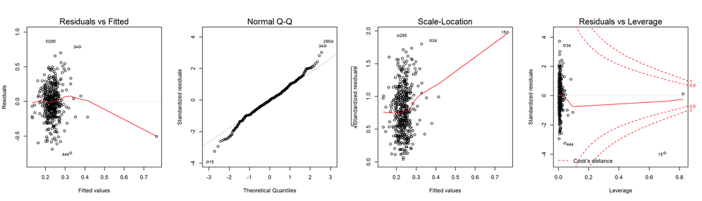

```r
par(mfrow=c(1,4))
plot(reg)
```

<footer></footer>

# Regression Analysis

### Heteroskedasticity

Breusch Pagan Test

```r
library(lmtest, lib.loc = "I:/R/library")
bptest(reg)
```

```
##
## 	studentized Breusch-Pagan test
##
## data:  reg
## BP = 33.823, df = 5, p-value = 2.583e-06
```

We can reject the null hypothesis that the variance of the residuals is constant `\(\rightarrow\)` heteroskedasticity

<footer></footer>

# Regression Analysis

### Heteroskedasticity

Non-adjusted standard errors

```r
coeftest(reg)
```

```
##
## t test of coefficients:
##
##                                   Estimate  Std. Error t value Pr(>|t|)
## (Intercept)                     3.6151e-01  2.2083e-01  1.6371  0.10229
## PE_RATIO                        8.4737e-04  2.8625e-04  2.9603  0.00323 **
## PCT_WOMEN_ON_BOARD             -2.8450e-03  1.2313e-03 -2.3105  0.02130 *
## BOARD_AVERAGE_TENURE           -3.3325e-04  3.6754e-03 -0.0907  0.92779
## BOARD_AVERAGE_AGE              -1.2055e-03  3.6011e-03 -0.3348  0.73796
## AVERAGE_BOD_TOTAL_COMPENSATION -1.8594e-09  3.5416e-08 -0.0525  0.95815
## ---
## Signif. codes:  0 '***' 0.001 '**' 0.01 '*' 0.05 '.' 0.1 ' ' 1
```

<footer></footer>

# Regression Analysis

### Heteroskedasticity

Heteroskedasticity-consistent standard errors

```r
library(sandwich)
coeftest(reg, vcov. = vcovHC(reg, "HC0"))
```

```
##
## t test of coefficients:
##
##                                   Estimate  Std. Error t value Pr(>|t|)
## (Intercept)                     3.6151e-01  2.4987e-01  1.4468  0.14862
## PE_RATIO                        8.4737e-04  5.5162e-04  1.5361  0.12518
## PCT_WOMEN_ON_BOARD             -2.8450e-03  1.4126e-03 -2.0140  0.04458 *
## BOARD_AVERAGE_TENURE           -3.3325e-04  3.5304e-03 -0.0944  0.92484
## BOARD_AVERAGE_AGE              -1.2055e-03  3.8963e-03 -0.3094  0.75717
## AVERAGE_BOD_TOTAL_COMPENSATION -1.8594e-09  1.6788e-08 -0.1108  0.91186
## ---
## Signif. codes:  0 '***' 0.001 '**' 0.01 '*' 0.05 '.' 0.1 ' ' 1
```

<footer></footer>

# Regression Analysis

### Multicollinearity

Variance inflation factors

```r
library(car, lib.loc = "I:/R/library")
vif(reg)
```

```
##                       PE_RATIO             PCT_WOMEN_ON_BOARD
##                       1.012047                       1.027449
##           BOARD_AVERAGE_TENURE              BOARD_AVERAGE_AGE
##                       1.256336                       1.249016
## AVERAGE_BOD_TOTAL_COMPENSATION
##                       1.003105
```

Interpretation: The square root of the variance inflation factor indicates how much larger the standard error increases compared to if that variable had 0 correlation to other predictor variables in the model.

```r
vif(reg)^(1/2)
```

```
##                       PE_RATIO             PCT_WOMEN_ON_BOARD
##                       1.006005                       1.013631
##           BOARD_AVERAGE_TENURE              BOARD_AVERAGE_AGE
##                       1.120864                       1.117594
## AVERAGE_BOD_TOTAL_COMPENSATION
##                       1.001551
```